# residential_displacement

suzanne

February 16, 2023

## Residential Displacement Analysis

This document looks at residential displacement data from the 2019 and 2021 travel surveys.

What share of households experienced residential displacement in 2019 and 2021?

To lookup variable names the codebook is here: J:\Data\Combined_Codebook_2021_With_Weights.xlsx

We will use the psrc.travesurvey package, documentation is here: https://psrc.github.io/psrc.travelsurvey/articles/calculate_hhts_summaries.html

Code is here: https://github.com/psrc/psrc.travelsurvey

### Background

3,044 households answered res_dur in 2019 2, 793 household answered res_dur in 2021

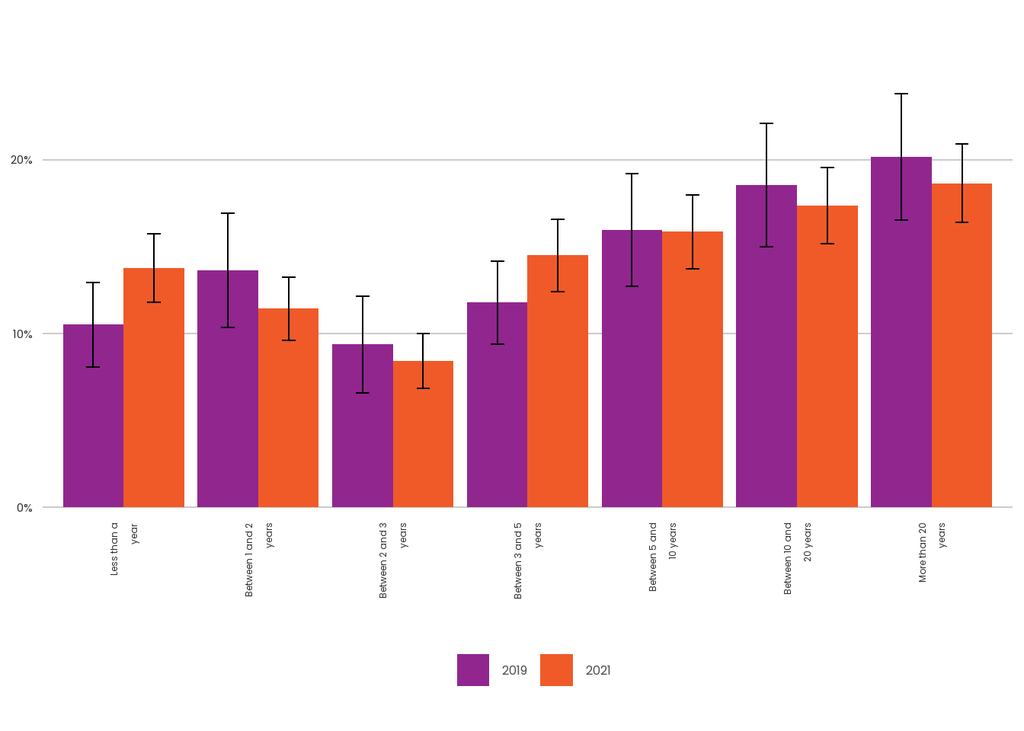

There may have been more movers in 2021 in the past year as compared to 2019.

Let’s analyze 2019 movers in the past 5 years for residential displacement (by itself first). Look at 1. prev_res_factors, 2. res_factors 3. by income, 4. by race and ethnicity;

this is 987 households. In the past five years for movers in WA, 29% of households had experienced displacement related reasons for moving.

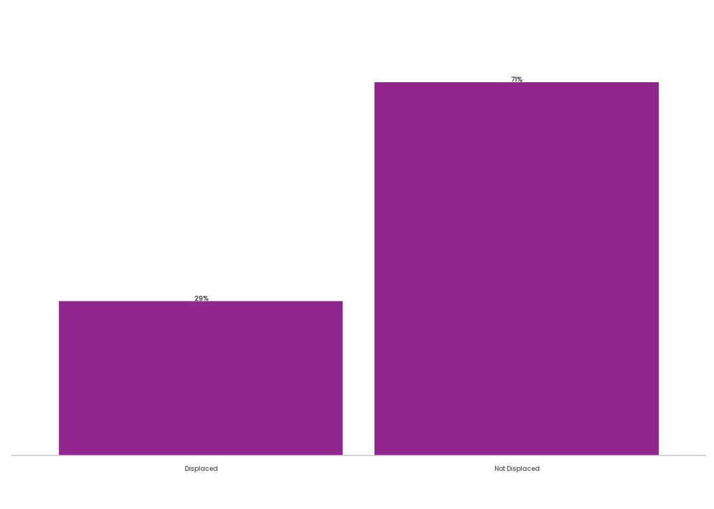

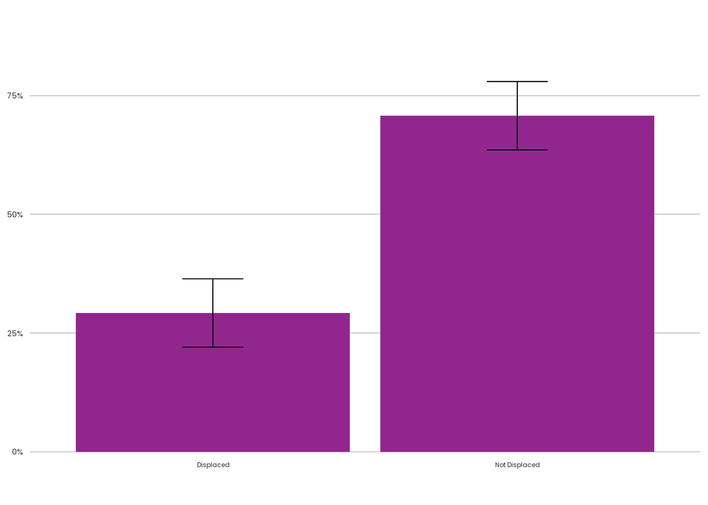

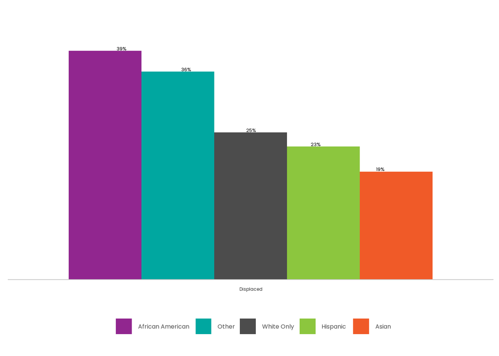

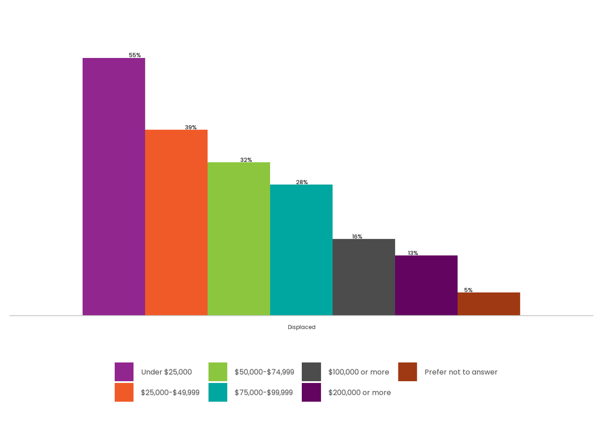

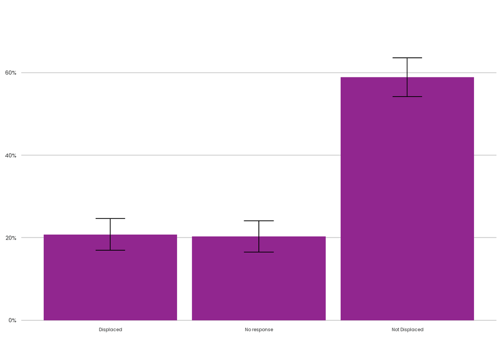

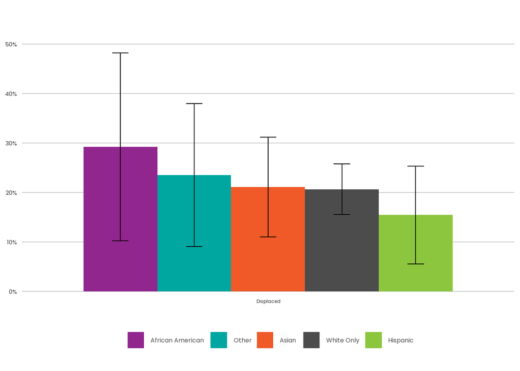

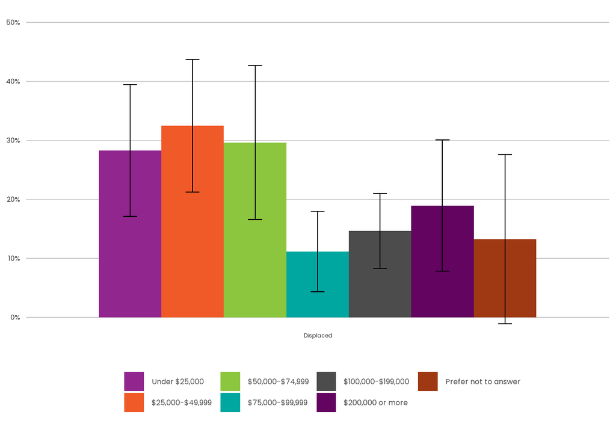

In 2019, there was a strong correlation between income and experiencing displacement. 55% of hhs with incomes of less than $25K experienced displacement. 13% of households with incomes over 200K

39% of African American hhs, 36% of other hhs experienced displacement, at higher rates than White Only, Hispanic, and Asian HHs

### By time frame

#### Past 5 years

Both datasets in the past 5 years (there is overlap in the time frame); no statistically significant difference (987 hhs in 2019, 860 in 2021)

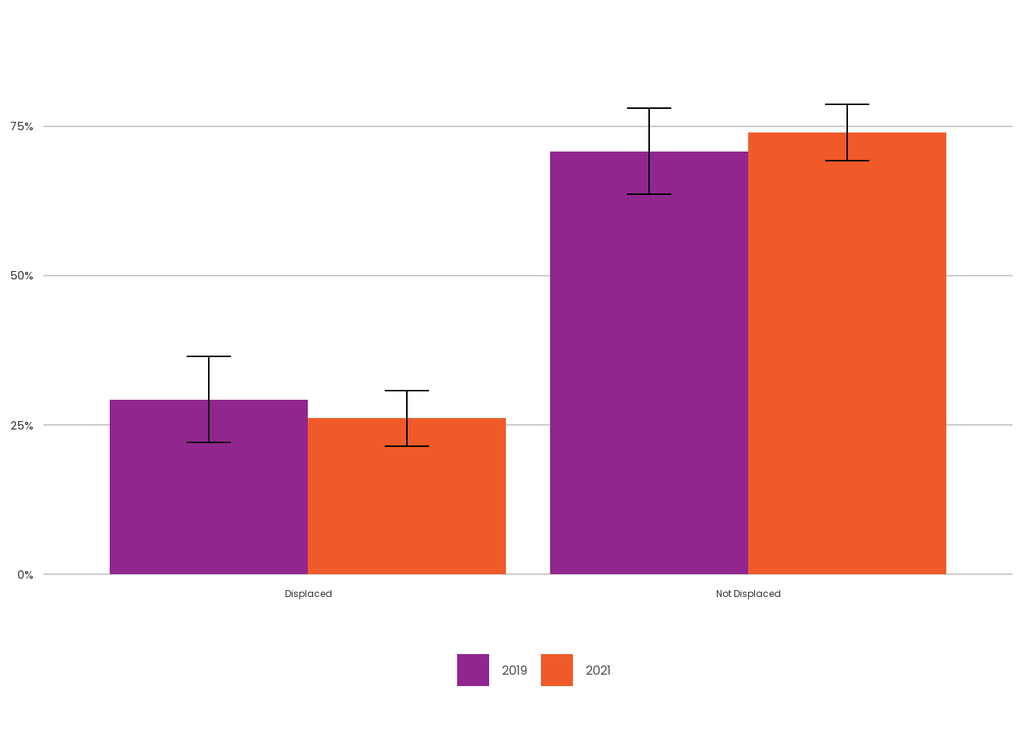

#### Past 2 years

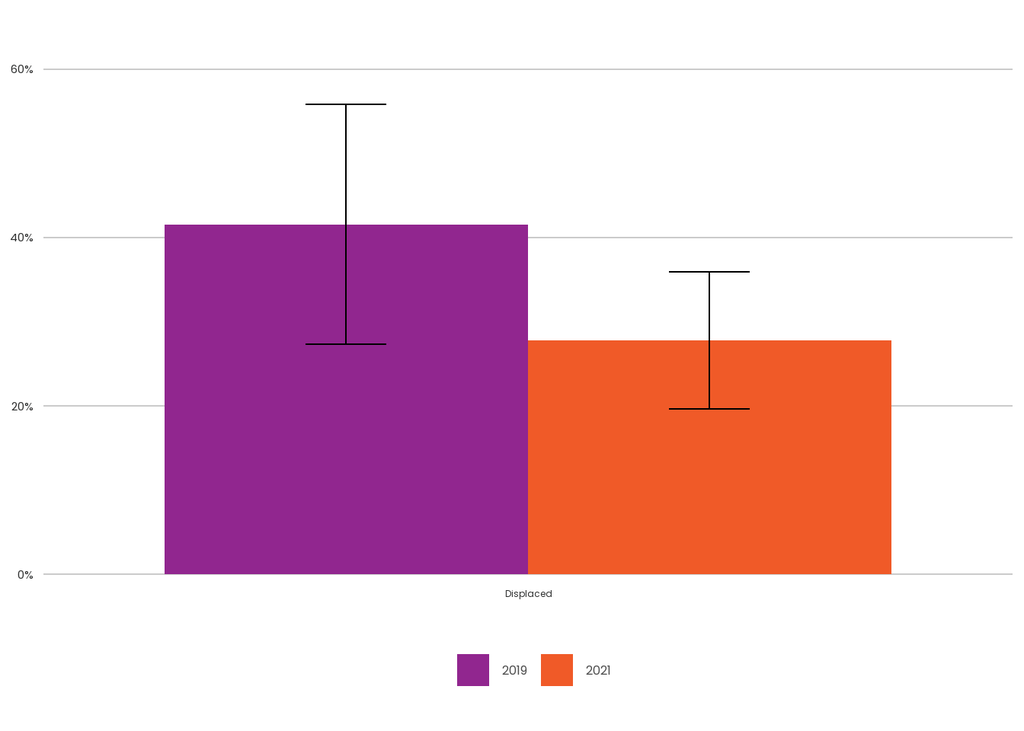

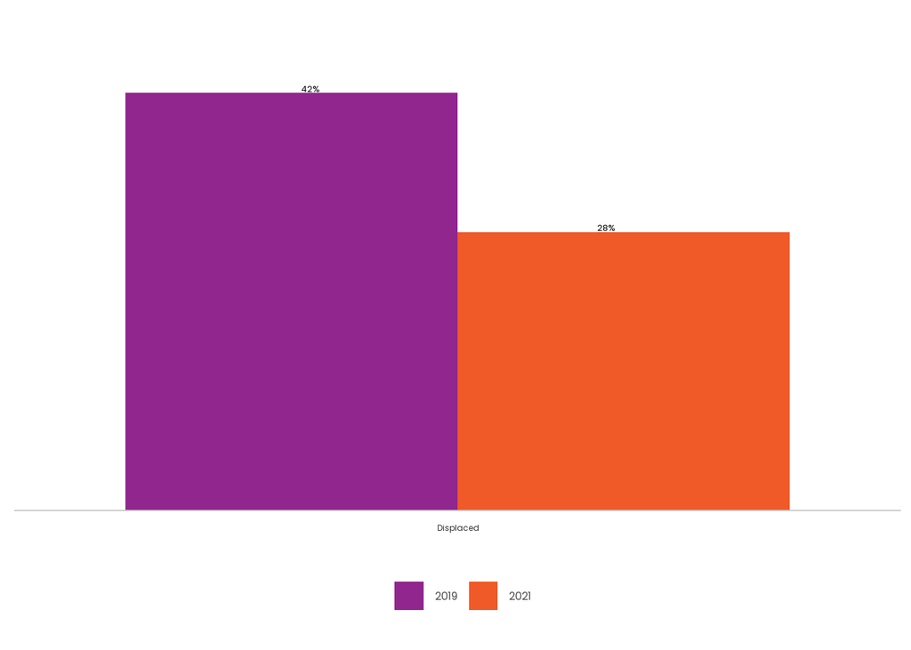

#### Past 1 year - all movers

Both datasets in the past 1 year (“Less than a year”). Limiting it to within one year of the survey means that there is no overlap between the samples and we are looking at the households that moved before COVID (spring/summer 2018-2019) and during COVID (spring/summer 2020-2021).

- 2019: 361
- 2021: 198

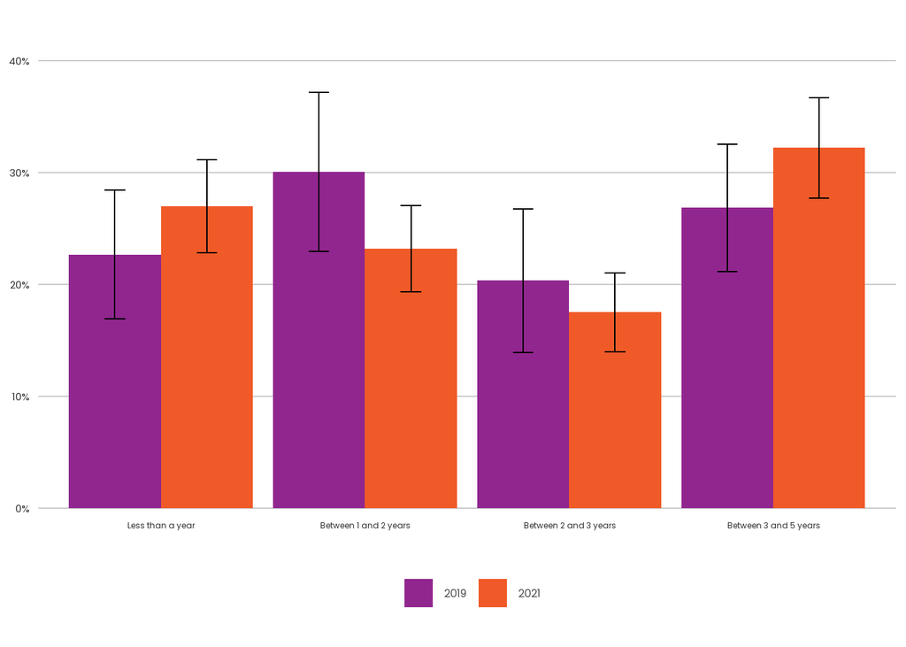

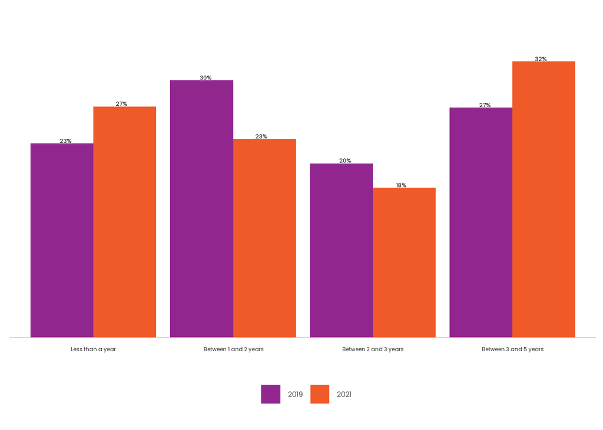

##### Race

###### 5 race categories

Both datasets in the past 1 year by **race**. The sample sizes by race and year are very small:

- African American: 14 | 9
- Asian: 68 | 47
- Hispanic: 25 | 17
- Other: 31 | 16
- White only: 204 | 101

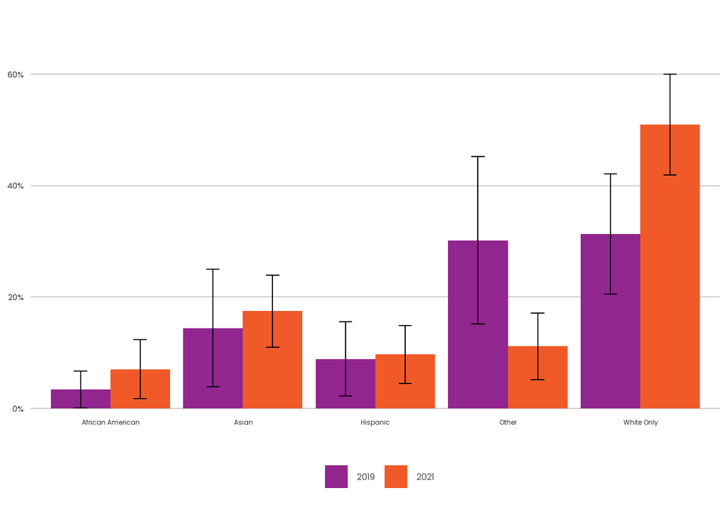

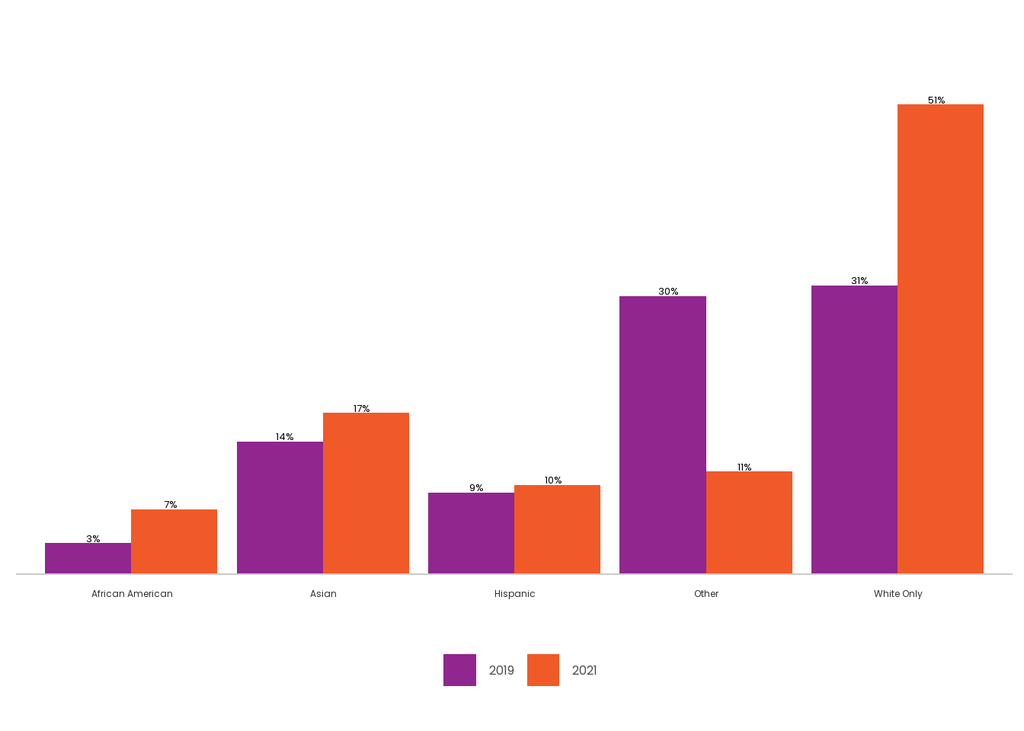

###### 3 race categories

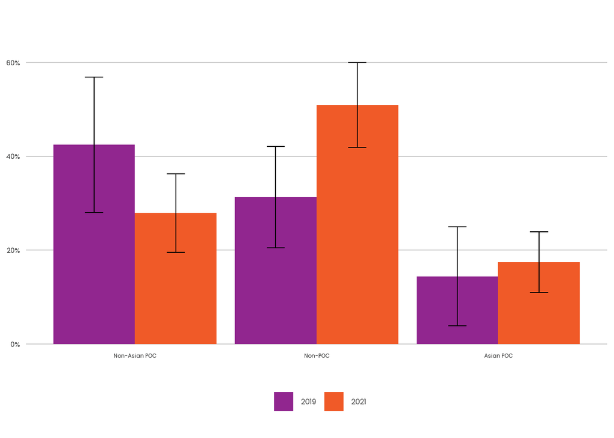

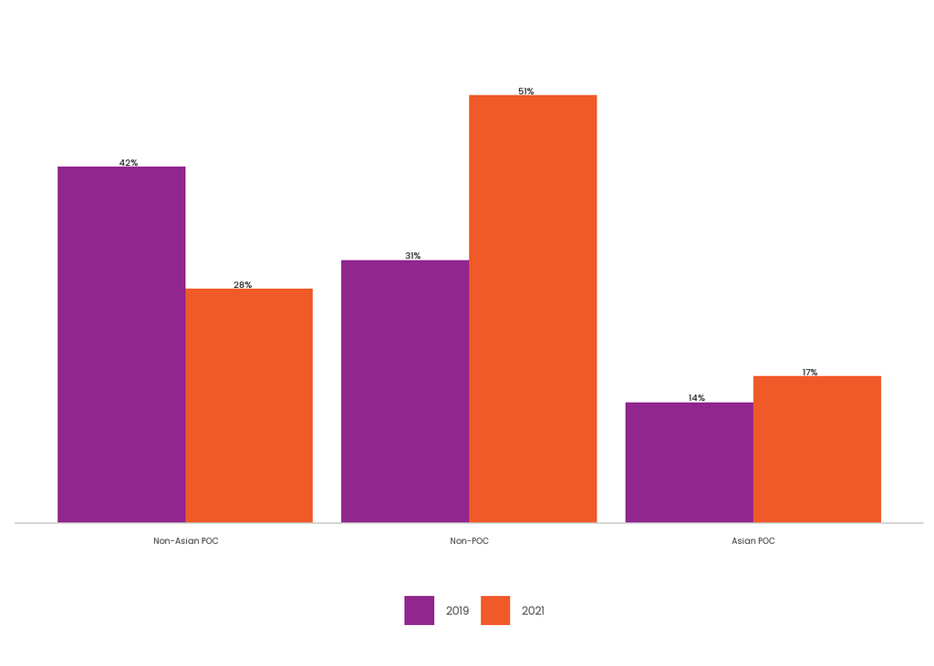

###### 2 race categories

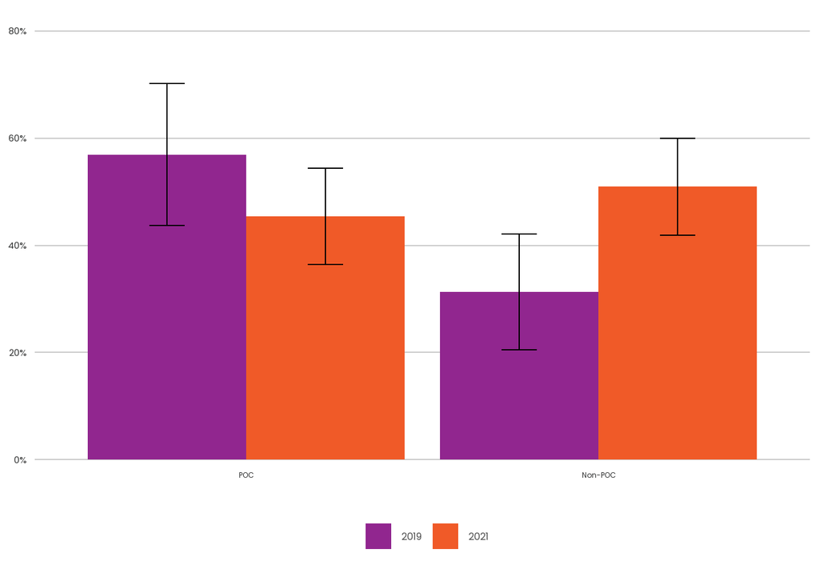

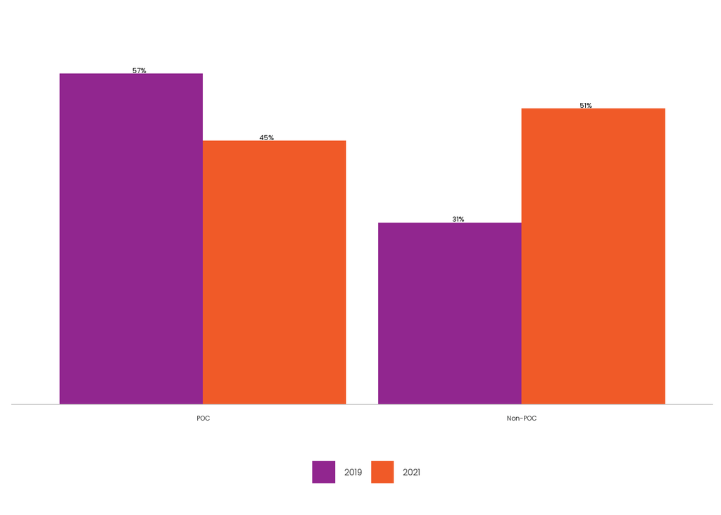

###### 2 race categories: 2017-2021

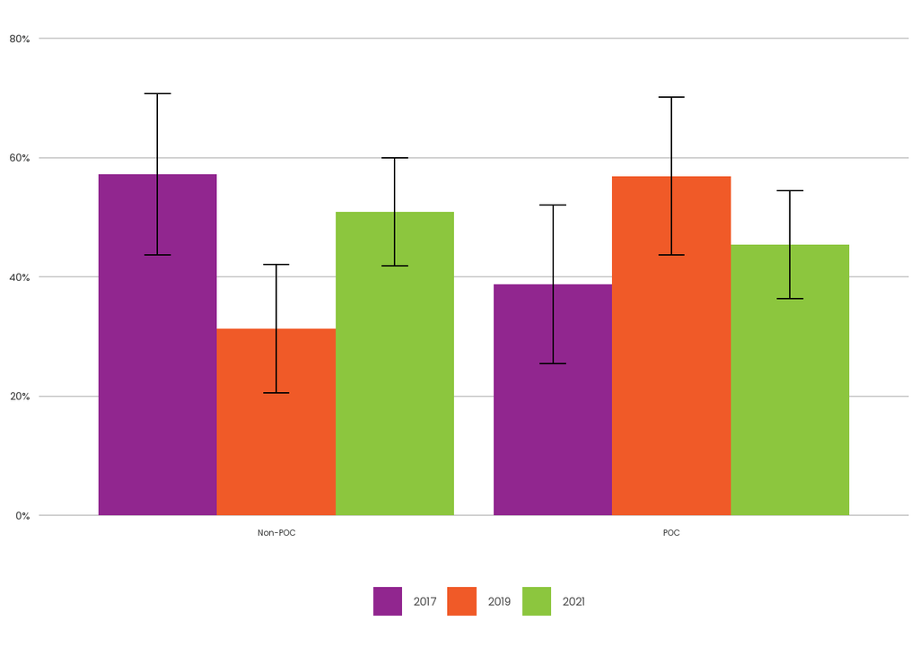

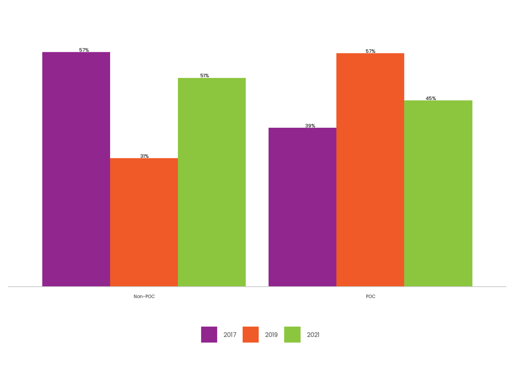

##### Income

Both datasets in the past 1 year by **income**. The sample sizes by race and year are very small:

- Under $25k: 34 | 17
- $25-49k 79 | 32
- $50-74k: 61 | 21
- $75-99k: 39 | 32
- $100-199k (only 2021): 59
- $100k+ (only 2019): 98
- $200k+: 39 | 27
- Prefer not to answer: 11 | 10

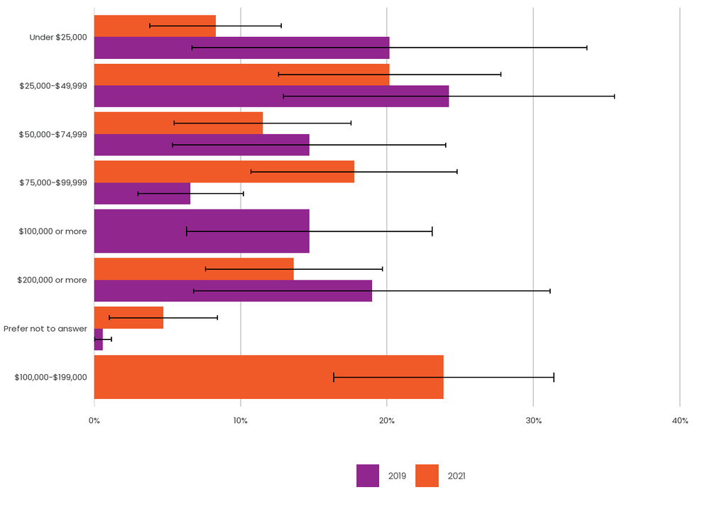

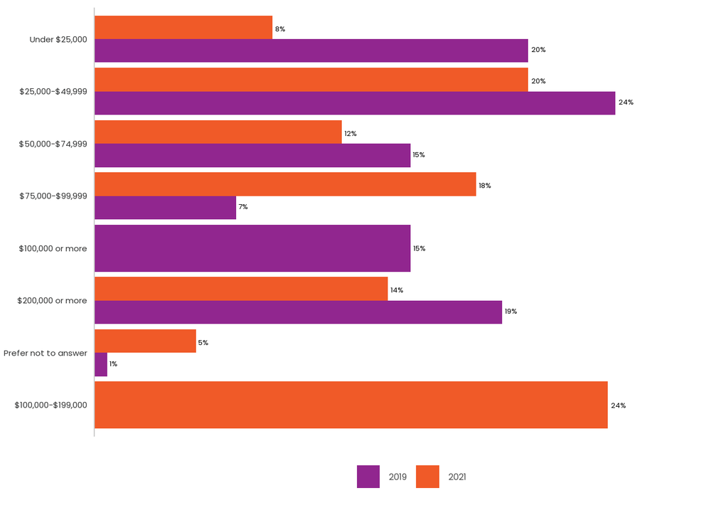

###### Simplified income categories

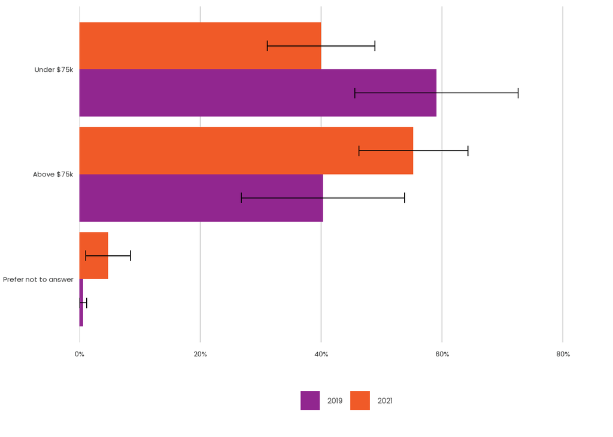

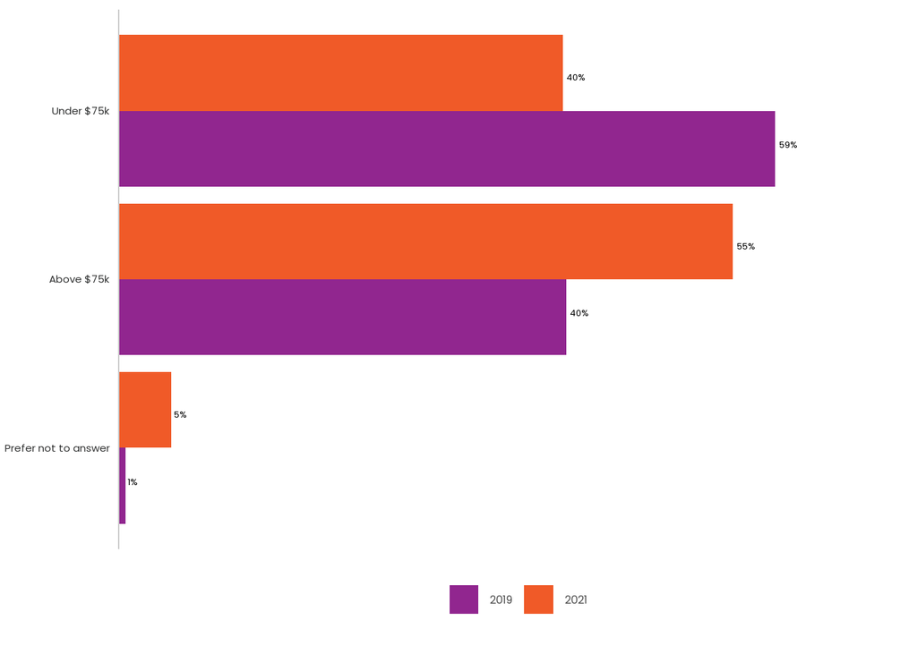

##### Regional growth center

Both data sets in the past 1 year by final home address location within or outside of a regional growth center. The moes are overlapping, but before COVID (2019 survey), people who moved within the past year moved to a location not in an RGC. After COVID (2021), there were more households who moved to areas within an RGC.

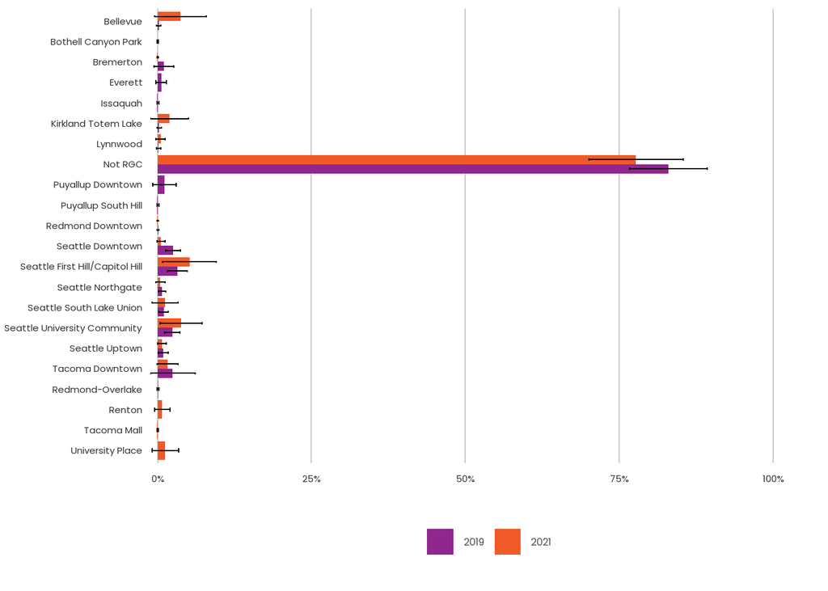

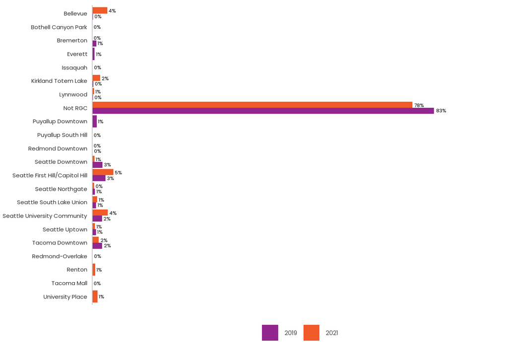

###### Simplified RGC: 3 categories

The RGS are categorized as urban or metro  
**Metro**: Bellevue, Bremerton, Everett, Redmond Downtown, Seattle Downtown, Seattle First Hill/Capitol Hill, Seattle Northgate, Seattle South Lake Union, Seattle University Community, Seattle Uptown, Tacoma Downtown  
**Urban** : Bothell Canyon Park, Issaquah, Kirkland Totem Lake, Lynnwood, Puyallup Downtown, Puyallup South Hill

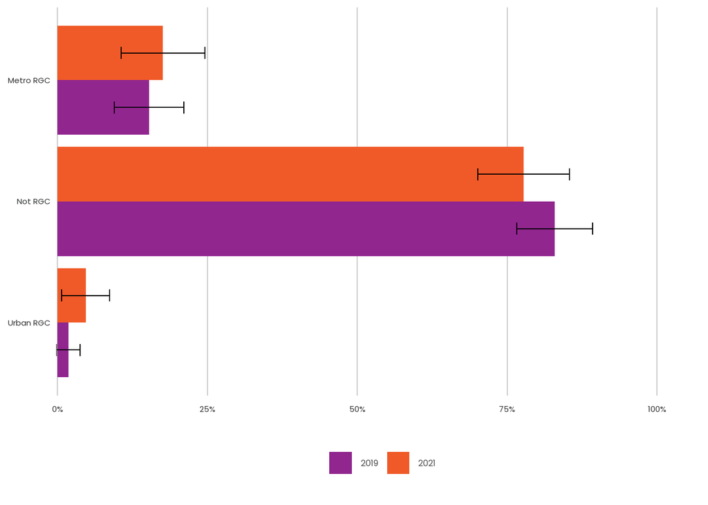

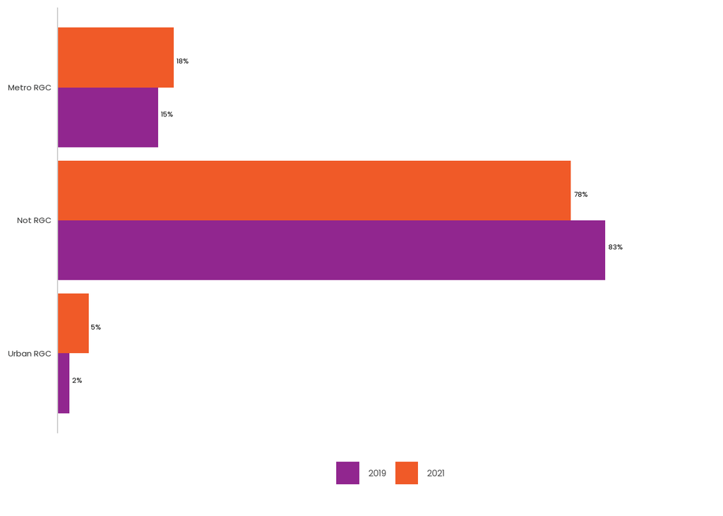

###### Simplified RGC: 2 categories

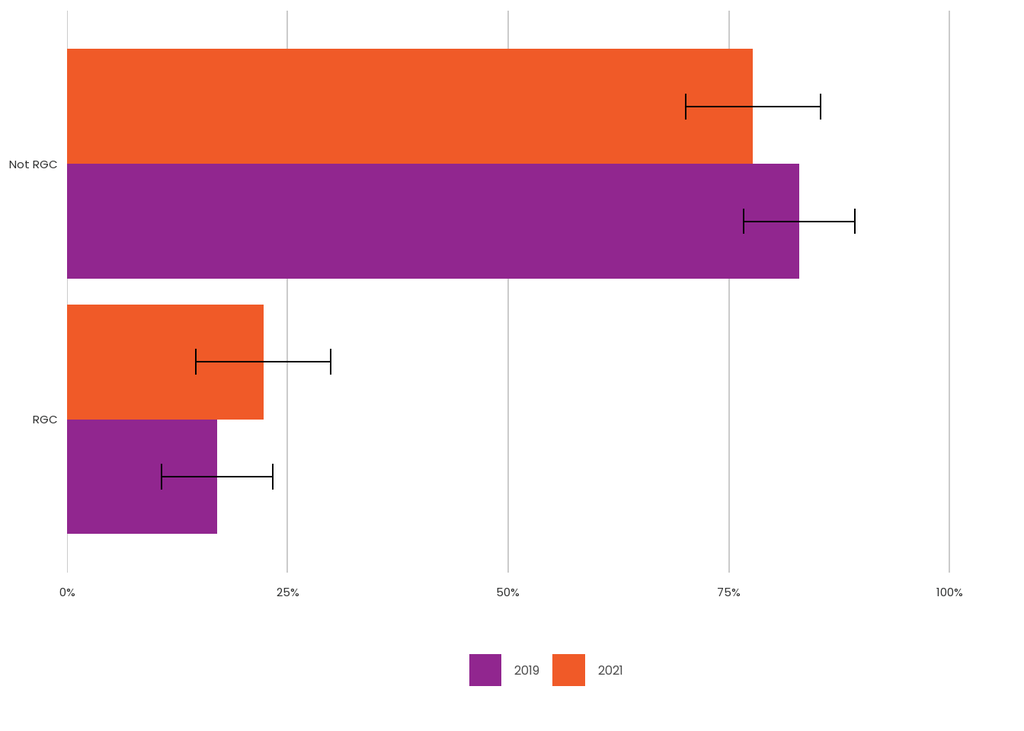

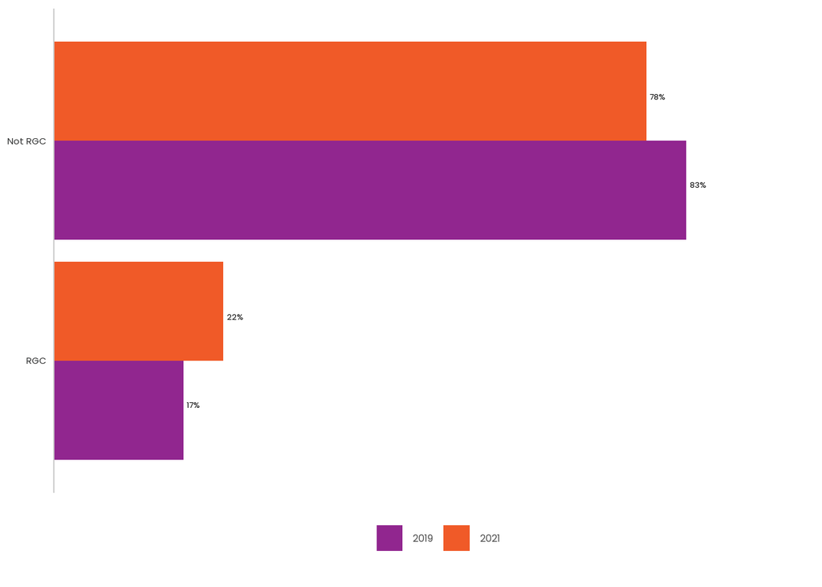